# Weight Lifting Prediction

Sonia Lebofsky

### Executive Summary

The following analysis involves building a prediction model from a weight lifting exercise dataset to predict whether or not a subject is lifting a barbell correctly. The experiment (as described at http://groupware.les.inf.puc-rio.br/har) involved placing accelerometers on a subjects belt, forearm, and arm and asking the subject to perform barbell lifts correctly and incorrectly in 5 different ways. The 5 different classes of barbell lift are as follows:

- A: Exactly according to specification
- B: Throwing the elbows to the front
- C: Lifting the dumbell only half way
- D: Lowering the dumbell only half way
- E: Throwing the hips to the front

The dataset used for training the prediction model includes measurements collected from the accelerometers and corresponding lifting class outcomes (“classe” variable).

After cleaning up the training dataset and dividing it further into a training set and validation set, the final model is trained using a random forest with 5-fold cross-validation. The validation set is used to predict the out-of-sample error, and in this case the model had an accuracy of about 98.9%, which is a 1.1% error rate. Thus the out-of-sample error on a prediction used on any further datasets would be just a little worse than 1%.

### Getting and Cleaning Data

The following analysis assumes that the data is downloaded into the same directory as the code. The training data set is downloaded from

https://d396qusza40orc.cloudfront.net/predmachlearn/pml-training.csv

and the test data set is downloaded from

https://d396qusza40orc.cloudfront.net/predmachlearn/pml-testing.csv.

The data sets are loaded into R, but it is important to note that for the remainder of this analysis, only the training data set is used. The testing data set is not used until the very final predictions once the model has been trained and built. While data cleaning is performed based on investigation of the training set, it is important that the same data cleaning is also applied to the test set for consistency.

```r
train_raw <- read.csv("pml-training.csv")
test_raw <- read.csv("pml-testing.csv")
```

Initial investigation of the training dataset shows that there are 19622 observations and 160 possible variables. It is desirable to reduce the number of variables and remove any that will not contribute effectively to the training of the model. From the structure of the dataset shown below, it can be seen that there are several variables that have missing values (NA).

```r
str(train_raw)
```

```
## 'data.frame':    19622 obs. of  160 variables:
##  $ X                       : int  1 2 3 4 5 6 7 8 9 10 ...
##  $ user_name               : Factor w/ 6 levels "adelmo","carlitos",..: 2 2 2 2 2 2 2 2 2 2 ...
##  $ raw_timestamp_part_1    : int  1323084231 1323084231 1323084231 1323084232 1323084232 1323084232 1323084232 1323084232 1323084232 1323084232 ...
##  $ raw_timestamp_part_2    : int  788290 808298 820366 120339 196328 304277 368296 440390 484323 484434 ...
##  $ cvtd_timestamp          : Factor w/ 20 levels "02/12/2011 13:32",..: 9 9 9 9 9 9 9 9 9 9 ...
##  $ new_window              : Factor w/ 2 levels "no","yes": 1 1 1 1 1 1 1 1 1 1 ...
##  $ num_window              : int  11 11 11 12 12 12 12 12 12 12 ...
##  $ roll_belt               : num  1.41 1.41 1.42 1.48 1.48 1.45 1.42 1.42 1.43 1.45 ...
##  $ pitch_belt              : num  8.07 8.07 8.07 8.05 8.07 8.06 8.09 8.13 8.16 8.17 ...
##  $ yaw_belt                : num  -94.4 -94.4 -94.4 -94.4 -94.4 -94.4 -94.4 -94.4 -94.4 -94.4 ...
##  $ total_accel_belt        : int  3 3 3 3 3 3 3 3 3 3 ...
##  $ kurtosis_roll_belt      : Factor w/ 397 levels "","-0.016850",..: 1 1 1 1 1 1 1 1 1 1 ...
##  $ kurtosis_picth_belt     : Factor w/ 317 levels "","-0.021887",..: 1 1 1 1 1 1 1 1 1 1 ...
##  $ kurtosis_yaw_belt       : Factor w/ 2 levels "","#DIV/0!": 1 1 1 1 1 1 1 1 1 1 ...
```

[output cut: 86 more lines]

The first step is to examine the proportion of missing values for each variable.

```r
na_percent <- sapply(train_raw, function(x) sum(is.na(x))/length(x))
table(na_percent)
```

```
## na_percent
##                 0 0.979308938946081
##                93                67
```

As can be seen from the above table, there are 93 variables that have zero missing values, and there are 67 variables that have 98% missing values, which is an extremely large percentage of missing data. Therefore, the variables with the 98% missing data are removed from the data set, as it is totally unreasonable to impute such a large amount of missing data.

```r
train <- train_raw[ ,(na_percent < 0.97)]
```

It is also desirable to remove any predictor variables that have zero variance (or near zero variance). These would be predictors that have very few unique values relative to the number of samples, and so have little information that can be used for prediction.

```r
predNZV <- nearZeroVar(train[ ,-93]) # don't want to include outcome variable, "classe"
train <- train[ ,-predNZV]
```

Additionally, since the outcome being predicted is related to movement, it is unlikely that any of the predictor variables that are not related to sensor measuements, such as the participant’s name, will be helpful for the prediction. Therefore, the first six columns of the data frame, which refer to the user name and id, as well as timestamp information, are removed.

```r
train <- train[ , -c(1:6)]
dim(train)
```

```
## [1] 19622    53
```

Now the train dataset has only 52 predictor variables plus the outcome variable “classe”, down from the original 160. Recall that the same cleaning performed above on the training dataset is also performed on the testing dataset for consistency. That is the same variables that were removed from the raw train set must be removed from the raw test set, as well as the last variable in the test set which is “problem_id” and is not a relevant predictor variable.

```r
test <- test_raw[ ,(na_percent < 0.97)]
test <- test[ ,-predNZV]
test <- test[, -c(1:6, 59)]
```

### Training and Validation

A random forest will be used to train the model. Random forest was chosen for its accuracy and because it can be used to assess variable importance for the model.

The first step for building the prediction model is to divide the cleaned train set into a training set and a validation set. This is done for the purpose of cross-validation. Models are trained on the training set and then tuned based on the accuracy of the validation set. The train set is divided such that 60% of the data is allocated to a training set and 40% is allocated to a validation set.

```r
library(caret)
inTrain <- createDataPartition(train$classe, p = 0.6, list = FALSE)
training <- train[inTrain, ]
validation <- train[-inTrain, ]
dim(training); dim(validation)
```

```
## [1] 11776    53
```

```
## [1] 7846   53
```

As mentioned, the training data includes 52 predictor variables (and the one outcome variable), which is still quite a large number of variables, especially when there is also 11776 observations. First attempts of using random forest to train the model with the 52 variables could not even be completed on my computer, even with the use of parallelization (it ran over night and was still not done). Therefore, it is of significant interest to reduce the number of variables even futher, without losing prediction accuracey. In order to do this, a small subset of about 10% of the training data is trained with random forest, from which “important variables” of the model can then be determined.

```r
inImpVars <- createDataPartition(training$classe, p = 0.1, list = FALSE)
trainImpVars <- training[inImpVars, ]
set.seed(1357)
modelImpVars <- train(classe ~., method = "rf", data = trainImpVars)
```

The plot below shows the relative importance of each of the predictor variables in the dataset. It can be seen that there are definitely some variables that have a much larger impact than others, and it is likely that only the top 50% of variables need be used for the model in order to still get an accurate result.

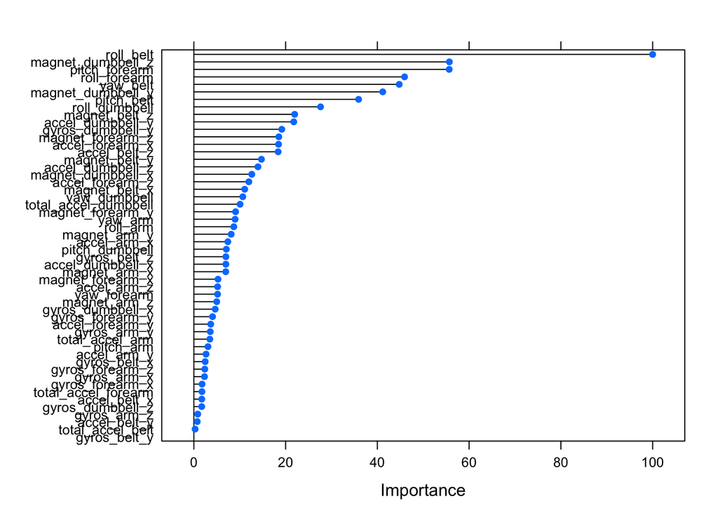

```r
ImpVars <- varImp(modelImpVars)
plot(ImpVars)
```

```r
summary(ImpVars$importance)
```

```
##     Overall
##  Min.   :  0.000
##  1st Qu.:  3.381
##  Median :  7.245
##  Mean   : 14.273
##  3rd Qu.: 18.388
##  Max.   :100.000
```

```r
training_red <- training[, ImpVars$importance > 14]
str(training_red)
```

```
## 'data.frame':    11776 obs. of  16 variables:
##  $ roll_belt        : num  1.41 1.48 1.42 1.42 1.45 1.43 1.42 1.45 1.55 1.57 ...
##  $ pitch_belt       : num  8.07 8.07 8.09 8.13 8.17 8.18 8.21 8.2 8.08 8.06 ...
##  $ yaw_belt         : num  -94.4 -94.4 -94.4 -94.4 -94.4 -94.4 -94.4 -94.4 -94.4 -94.4 ...
##  $ accel_belt_z     : int  22 24 21 21 22 23 21 22 21 21 ...
##  $ magnet_belt_y    : int  599 600 599 603 609 602 598 597 600 603 ...
##  $ magnet_belt_z    : int  -313 -302 -311 -313 -308 -319 -310 -310 -316 -313 ...
##  $ roll_dumbbell    : num  13.1 13.4 13.1 12.8 13.3 ...
##  $ gyros_dumbbell_y : num  -0.02 -0.02 -0.02 -0.02 -0.02 -0.02 -0.02 -0.02 -0.02 -0.02 ...
##  $ accel_dumbbell_y : int  47 48 47 46 48 47 48 47 47 47 ...
##  $ magnet_dumbbell_y: int  293 292 295 300 291 291 295 294 292 295 ...
##  $ magnet_dumbbell_z: num  -65 -68 -70 -74 -69 -65 -68 -63 -62 -74 ...
##  $ roll_forearm     : num  28.4 28 27.9 27.8 27.7 27.5 27.2 27.2 27 26.9 ...
##  $ pitch_forearm    : num  -63.9 -63.9 -63.9 -63.8 -63.8 -63.8 -63.9 -63.9 -64 -64 ...
##  $ accel_forearm_x  : int  192 189 195 193 190 191 193 192 192 192 ...
##  $ magnet_forearm_z : num  476 473 470 474 473 478 478 472 472 466 ...
##  $ classe           : Factor w/ 5 levels "A","B","C","D",..: 1 1 1 1 1 1 1 1 1 1 ...
```

```r
validation_red <- validation[, ImpVars$importance > 14]
```

Now the model can be trained using the full number of observations (with the reduced number of variables). Note that cross-validation is used for the random forest, with number of folds chosen to be 5 (as folds between 3 to 10 are typical).

```r
set.seed(2468)
modelrf <- train(classe ~ ., method = "rf", data = training_red, trControl = trainControl(method = "cv", number = 5, allowParallel = TRUE))
```

With the model built, the validation dataset is used to estimate what the out-of-sample accuracy would be. From the prediction summary below, it can be seen that the validation prediction has an accuracy of about 98.9% (or an error of about 1.1%). Therefore, it is reasonable to assume that predictions on any other dataset would be a little bit worse than 1% error.

```r
modelrf$finalModel
```

```
##
## Call:
##  randomForest(x = x, y = y, mtry = param$mtry)
##                Type of random forest: classification
##                      Number of trees: 500
## No. of variables tried at each split: 2
##
##         OOB estimate of  error rate: 1.27%
## Confusion matrix:
##      A    B    C    D    E class.error
## A 3332   10    1    3    2 0.004778973
## B   24 2236   17    2    0 0.018867925
## C    1   15 2024   14    0 0.014605648
## D    2    1   30 1893    4 0.019170984
## E    0    7    3   13 2142 0.010623557
```

```r
predVal <- predict(modelrf, validation_red)
confusionMatrix(predVal, validation_red$classe)
```

```
## Confusion Matrix and Statistics
##
##           Reference
## Prediction    A    B    C    D    E
##          A 2226   16    1    1    0
##          B    4 1492    8    0    4
##          C    2    8 1348   22    5
##          D    0    2   11 1263    1
##          E    0    0    0    0 1432
##
## Overall Statistics
##
##                Accuracy : 0.9892
##                  95% CI : (0.9866, 0.9913)
##     No Information Rate : 0.2845
##     P-Value [Acc > NIR] : < 2.2e-16
##
##                   Kappa : 0.9863
##  Mcnemar's Test P-Value : NA
##
## Statistics by Class:
##
##                      Class: A Class: B Class: C Class: D Class: E
## Sensitivity            0.9973   0.9829   0.9854   0.9821   0.9931
## Specificity            0.9968   0.9975   0.9943   0.9979   1.0000
## Pos Pred Value         0.9920   0.9894   0.9733   0.9890   1.0000
## Neg Pred Value         0.9989   0.9959   0.9969   0.9965   0.9984
## Prevalence             0.2845   0.1935   0.1744   0.1639   0.1838
## Detection Rate         0.2837   0.1902   0.1718   0.1610   0.1825
## Detection Prevalence   0.2860   0.1922   0.1765   0.1628   0.1825
## Balanced Accuracy      0.9971   0.9902   0.9898   0.9900   0.9965
```

### Final Prediction

The final model is run on the provided test set in order to make predictions on the lifting class.

```r
test_red <- test[ , ImpVars$importance > 14]
predTest <- predict(modelrf, test_red)
predTest
```

```
##  [1] B A B A A E D B A A B C B A E E A B B B
## Levels: A B C D E
```

```r
pml_write_files = function(x){
    n = length(x)
    for(i in 1:n){
        filename = paste0("problem_id_",i,".txt")
        write.table(x[i],file=filename,quote=FALSE,row.names=FALSE,col.names=FALSE)
    }
}
setwd("./test_predictions")
pml_write_files(predTest)
setwd("./..")
```